# Chapter 4 Assignment

Joe Dickerson

2025-09-14

Question 13.

When looking at the scatterplot matrices with the pairs() function, the most notable pattern is between Year and Volume. Producing a scatterplot of those two variables shows the volume increase as the years increase. This is not unexpected based on an understanding of how the S&P tends to grow with the economy.

```r
summary(Weekly)
```

```
##       Year           Lag1               Lag2               Lag3
##  Min.   :1990   Min.   :-18.1950   Min.   :-18.1950   Min.   :-18.1950
##  1st Qu.:1995   1st Qu.: -1.1540   1st Qu.: -1.1540   1st Qu.: -1.1580
##  Median :2000   Median :  0.2410   Median :  0.2410   Median :  0.2410
##  Mean   :2000   Mean   :  0.1506   Mean   :  0.1511   Mean   :  0.1472
##  3rd Qu.:2005   3rd Qu.:  1.4050   3rd Qu.:  1.4090   3rd Qu.:  1.4090
##  Max.   :2010   Max.   : 12.0260   Max.   : 12.0260   Max.   : 12.0260
##       Lag4               Lag5              Volume            Today
##  Min.   :-18.1950   Min.   :-18.1950   Min.   :0.08747   Min.   :-18.1950
##  1st Qu.: -1.1580   1st Qu.: -1.1660   1st Qu.:0.33202   1st Qu.: -1.1540
##  Median :  0.2380   Median :  0.2340   Median :1.00268   Median :  0.2410
##  Mean   :  0.1458   Mean   :  0.1399   Mean   :1.57462   Mean   :  0.1499
##  3rd Qu.:  1.4090   3rd Qu.:  1.4050   3rd Qu.:2.05373   3rd Qu.:  1.4050
##  Max.   : 12.0260   Max.   : 12.0260   Max.   :9.32821   Max.   : 12.0260
##  Direction
##  Down:484
##  Up  :605
##
##
##
##
```

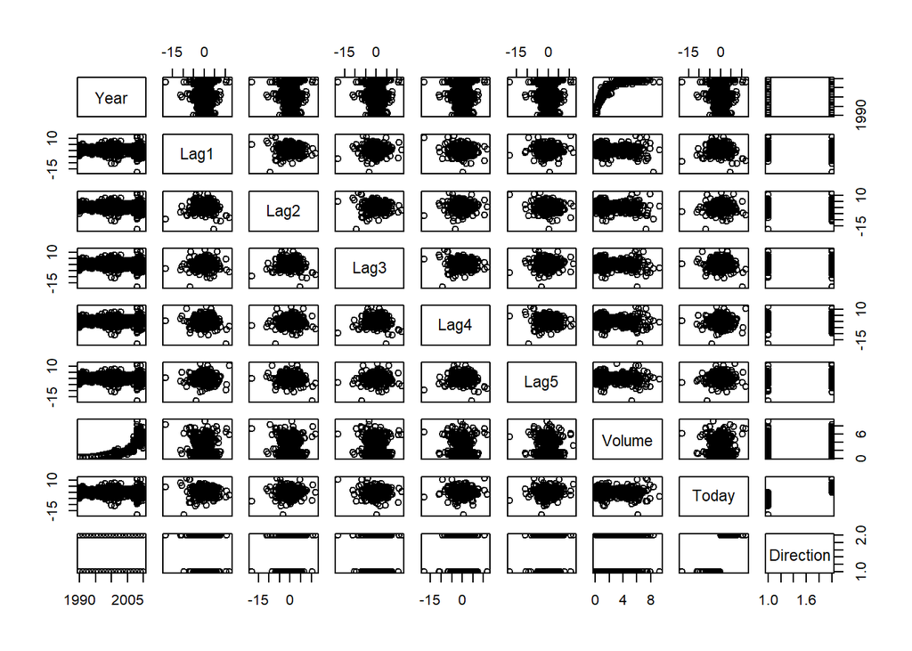

```r
pairs(Weekly)
```

```r
cor(Weekly[,-9])
```

```
##               Year         Lag1        Lag2        Lag3         Lag4
## Year    1.00000000 -0.032289274 -0.03339001 -0.03000649 -0.031127923
## Lag1   -0.03228927  1.000000000 -0.07485305  0.05863568 -0.071273876
## Lag2   -0.03339001 -0.074853051  1.00000000 -0.07572091  0.058381535
## Lag3   -0.03000649  0.058635682 -0.07572091  1.00000000 -0.075395865
## Lag4   -0.03112792 -0.071273876  0.05838153 -0.07539587  1.000000000
## Lag5   -0.03051910 -0.008183096 -0.07249948  0.06065717 -0.075675027
## Volume  0.84194162 -0.064951313 -0.08551314 -0.06928771 -0.061074617
## Today  -0.03245989 -0.075031842  0.05916672 -0.07124364 -0.007825873
##                Lag5      Volume        Today
## Year   -0.030519101  0.84194162 -0.032459894
## Lag1   -0.008183096 -0.06495131 -0.075031842
## Lag2   -0.072499482 -0.08551314  0.059166717
## Lag3    0.060657175 -0.06928771 -0.071243639
## Lag4   -0.075675027 -0.06107462 -0.007825873
## Lag5    1.000000000 -0.05851741  0.011012698
## Volume -0.058517414  1.00000000 -0.033077783
## Today   0.011012698 -0.03307778  1.000000000
```

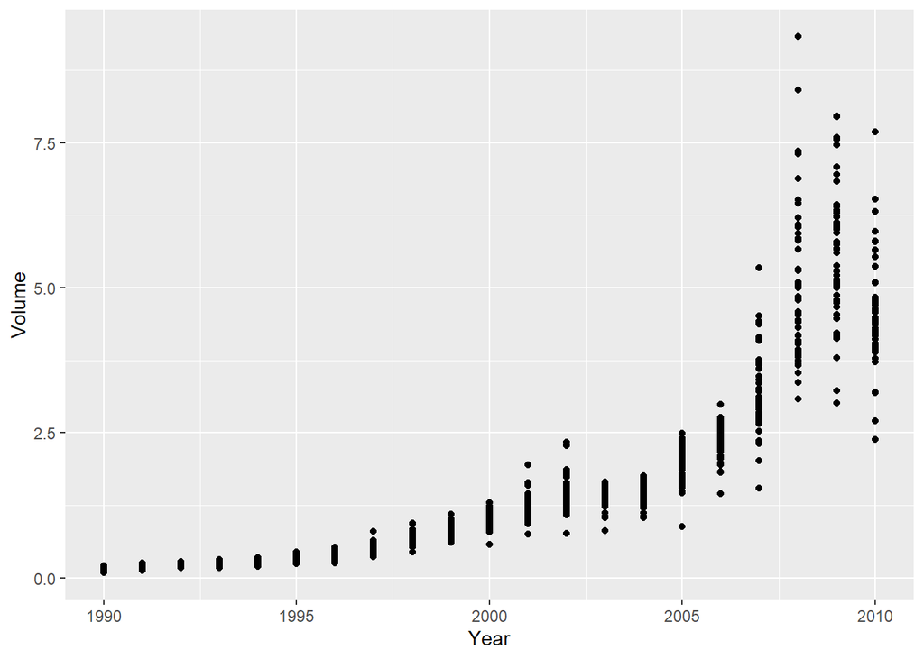

```r
Weekly %>%
  ggplot(aes(x = Year, y = Volume)) +
  geom_point()
```

The summary output of the model shows only Lag2 has statistical significance with a p-value of 0.0296.

```r
glmod <- glm(Direction ~ Lag1 + Lag2 + Lag3 + Lag4 + Lag5 + Volume, family = binomial, data = Weekly)

summary(glmod)
```

```
##
## Call:
## glm(formula = Direction ~ Lag1 + Lag2 + Lag3 + Lag4 + Lag5 +
##     Volume, family = binomial, data = Weekly)
##
## Coefficients:
##             Estimate Std. Error z value Pr(>|z|)
## (Intercept)  0.26686    0.08593   3.106   0.0019 **
## Lag1        -0.04127    0.02641  -1.563   0.1181
## Lag2         0.05844    0.02686   2.175   0.0296 *
## Lag3        -0.01606    0.02666  -0.602   0.5469
## Lag4        -0.02779    0.02646  -1.050   0.2937
## Lag5        -0.01447    0.02638  -0.549   0.5833
## Volume      -0.02274    0.03690  -0.616   0.5377
## ---
## Signif. codes:  0 '***' 0.001 '**' 0.01 '*' 0.05 '.' 0.1 ' ' 1
##
## (Dispersion parameter for binomial family taken to be 1)
##
##     Null deviance: 1496.2  on 1088  degrees of freedom
## Residual deviance: 1486.4  on 1082  degrees of freedom
## AIC: 1500.4
##
## Number of Fisher Scoring iterations: 4
```

The diagonals indicate the correct predictions, so there are (557 + 54) correct predictions.

nrow(Weekly) = 1089

611 / 1089 = 0.5611

This can be confirmed using mean().

```r
## Creating a prediction table

glm.probs <- predict(glmod, type = "response")
glm.probs[1:10]
```

```
##         1         2         3         4         5         6         7         8
## 0.6086249 0.6010314 0.5875699 0.4816416 0.6169013 0.5684190 0.5786097 0.5151972
##         9        10
## 0.5715200 0.5554287
```

```r
contrasts(Weekly$Direction)
```

```
##      Up
## Down  0
## Up    1
```

```r
## table(glmod, Weekly$Direction)

glm.pred <- rep("Down", nrow(Weekly))
glm.pred[glm.probs > 0.5] = "Up"

summary(glm.pred)
```

```
##    Length     Class      Mode
##      1089 character character
```

```r
## Producing the confusion matrix
table(glm.pred, Weekly$Direction)
```

```
##
## glm.pred Down  Up
##     Down   54  48
##     Up    430 557
```

```r
611 / nrow(Weekly)
```

```
## [1] 0.5610652
```

```r
mean(glm.pred == Weekly$Direction)
```

```
## [1] 0.5610652
```

```r
train <- (Weekly$Year < 2009)

weekly.2009 <- Weekly[!train,]

direction.2009 <- Weekly$Direction[!train]

glmod2 <- glm(Direction ~ Lag2, data = Weekly, family = binomial, subset = train)
glm.probs2 <- predict(glmod2, weekly.2009, type = "response")

glm.pred2 <- rep("Down", nrow(weekly.2009))

glm.pred2[glm.probs2 > 0.5] <- "Up"

table(glm.pred2, direction.2009)
```

```
##          direction.2009
## glm.pred2 Down Up
##      Down    9  5
##      Up     34 56
```

```r
mean(glm.pred2 == direction.2009)
```

```
## [1] 0.625
```

```r
mean(glm.pred2 != direction.2009)
```

```
## [1] 0.375
```

We repeat the process with LDA, and the fraction of correct predictions is 62.5%:

```r
library(MASS)
lda.fit <- lda(Direction ~ Lag2, data = Weekly, subset = train)

summary(lda.fit)
```

```
##         Length Class  Mode
## prior   2      -none- numeric
## counts  2      -none- numeric
## means   2      -none- numeric
## scaling 1      -none- numeric
## lev     2      -none- character
## svd     1      -none- numeric
## N       1      -none- numeric
## call    4      -none- call
## terms   3      terms  call
## xlevels 0      -none- list
```

```r
lda.pred <- predict(lda.fit, weekly.2009)
names(lda.pred)
```

```
## [1] "class"     "posterior" "x"
```

```r
lda.class <- lda.pred$class

table(lda.class, direction.2009)
```

```
##          direction.2009
## lda.class Down Up
##      Down    9  5
##      Up     34 56
```

```r
mean(lda.class == direction.2009)
```

```
## [1] 0.625
```

We repeat the process for QDA, and the fraction of correct predictions is 0.587:

```r
qda.fit <- qda(Direction ~ Lag2, data = Weekly, subset = train)

qda.class <- predict(qda.fit, weekly.2009)$class

table(qda.class, direction.2009)
```

```
##          direction.2009
## qda.class Down Up
##      Down    0  0
##      Up     43 61
```

```r
mean(qda.class == direction.2009)
```

```
## [1] 0.5865385
```

We repeat the process for KNN with K=1 and get 0.5 as the fraction of correct predictions:

```r
library(class)

train.X <- as.matrix(Weekly$Lag2[train])
test.X <- as.matrix(Weekly$Lag2[!train])
train.Direction <- Weekly$Direction[train]

knn.pred <- knn(train.X, test.X, train.Direction, k = 1)
table(knn.pred, direction.2009)
```

```
##         direction.2009
## knn.pred Down Up
##     Down   21 30
##     Up     22 31
```

```r
mean(knn.pred == direction.2009)
```

```
## [1] 0.5
```

We repeat the for naive Bayes and get 0.5865 as the fraction of correct predictions:

```r
library(e1071)
nb.fit <- naiveBayes(Direction ~ Lag2, data = Weekly, subset = train)

nb.class <- predict(nb.fit, weekly.2009)

table(nb.class, direction.2009)
```

```
##         direction.2009
## nb.class Down Up
##     Down    0  0
##     Up     43 61
```

```r
mean(nb.class == direction.2009)
```

```
## [1] 0.5865385
```

The confusion matrix in the model that includes both Lag1 and Volume with Lag2 is similar to the confusion matrix that contains Lag2 alone. The KNN model is less effective with these additional predictors and K set to 3. Overall, it seems the model works best with Lag2 as the only predictor based on the additional exploration.

```r
glmod2 <- glm(Direction ~ Lag2 + Volume, family = binomial, data = Weekly)

glmod3 <- glm(Direction ~ Lag1 + Lag2 + Volume, family = binomial, data = Weekly)


glm.probs3 <- predict(glmod3, type = "response")
glm.probs3[1:10]
```

```
##         1         2         3         4         5         6         7         8
## 0.5762733 0.5759227 0.5825428 0.4888569 0.6049910 0.5602960 0.5917236 0.5335580
##         9        10
## 0.5727966 0.5498698
```

```r
contrasts(Weekly$Direction)
```

```
##      Up
## Down  0
## Up    1
```

```r
glm.pred3 <- rep("Down", nrow(Weekly))
glm.pred3[glm.probs3 > 0.5] = "Up"

summary(glm.pred3)
```

```
##    Length     Class      Mode
##      1089 character character
```

```r
table(glm.pred3, Weekly$Direction)
```

```
##
## glm.pred3 Down  Up
##      Down   47  40
##      Up    437 565
```

```r
611 / nrow(Weekly)
```

```
## [1] 0.5610652
```

```r
mean(glm.pred3 == Weekly$Direction)
```

```
## [1] 0.5619835
```

```r
####


glmod4 <- glm(Direction ~ Lag1 + Lag2 + Volume, data = Weekly, family = binomial, subset = train)

glm.probs4 <- predict(glmod4, weekly.2009, type = "response")

glm.pred4 <- rep("Down", nrow(weekly.2009))

glm.pred4[glm.probs4 > 0.5] <- "Up"

table(glm.pred4, direction.2009)
```

```
##          direction.2009
## glm.pred4 Down Up
##      Down   27 33
##      Up     16 28
```

```r
mean(glm.pred4 == direction.2009)
```

```
## [1] 0.5288462
```

```r
mean(glm.pred4 != direction.2009)
```

```
## [1] 0.4711538
```

```r
library(class)

train.X2 <- cbind(Weekly$Lag1, Weekly$Lag2, Weekly$Volume)[train,]
test.X2 <- cbind(Weekly$Lag1, Weekly$Lag2, Weekly$Volume)[!train,]
train.Direction <- Weekly$Direction[train]

knn.pred <- knn(train.X2, test.X2, train.Direction, k = 3)

table(knn.pred, direction.2009)
```

```
##         direction.2009
## knn.pred Down Up
##     Down   27 38
##     Up     16 23
```

```r
mean(knn.pred == direction.2009)
```

```
## [1] 0.4807692
```